# Shape-Aware Deep Learning for Models of Production

Yu Ma* Artem Prokhorov** Huiyan Sang* Zheng Wei*

*Texas A&M University  
**University of Sydney, CIREQ & CEBDA

June 2026

### Standard SFM problem

$$Y_i = f(X_i) + V_i - U_i,
\qquad U_i \ge 0$$

- parametric $f(\cdot)$ interpretable but rigid
- nonparametric $f(\cdot)$ flexible but can violate production theory, aka shape constraints

**Nonparametric SFM**: Fan et al. (1996), Kumbhakar et al. (2007), Parmeter and Racine (2012), Ferrara and Vidoli (2017), Tran et al. (2023)

**DNN for SFM**: Wang (1996, 2003), Tsionas and Mamatzakis (2019), Tsionas (2022), Tsionas et al. (2023), Kutlu and Mao (2024)

**Main idea:** use deep neural networks, but build monotonicity and concavity into the architecture rather than hoping the fitted curve behaves itself.

$\Rightarrow$ `shape-aware` `learning`

### What’s a DNN?

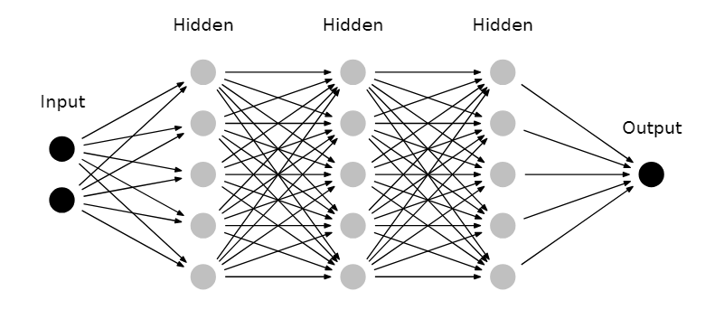

Flexible nonparametric approximation via hidden layers and activation functions.

**Approximation theory** (Hornik et al., 1989; Cybenko, 1989): single-layer perceptron (shaller NN) approximates any continuous function to a desired degree of accuracy.

**Multi-layer networks** (deep NN): greater flexibility and generalization especially for high-dimensions, interactions and nonlineary (Hornik, 1991; Poggio et al., 2017)

### What’s DNN-SFM?

Layer 0: inputs $\mathbf{h}^{(0)}=\mathbf{X}=(X_1,\ldots,X_K)^\top$ inputs of production

Layer $L$: output $Y = {\mathbf{h}^{(L)}}+ V-U$,

where ${\mathbf{h}^{(L)}}$ is defined recursively using an **activation function** $\sigma^{(\ell)}$:
$$\mathbf{h}^{(\ell)} = \sigma^{(\ell)}\left(W^{(\ell)}\mathbf{h}^{(\ell-1)}+\mathbf{w}_0^{\ell}\right), \qquad \ell = 1,\ldots,L.$$

$$\underbrace{
\begin{pmatrix}
h_1^{(\ell)}\\
h_2^{(\ell)}\\
\vdots\\
h_{K^{(\ell)}}^{(\ell)}\\
\end{pmatrix}}_{\mathbf{h}^{(\ell)}} =
\begin{pmatrix}
\sigma^{(\ell)}(o_1^{(\ell)})\\
\sigma^{(\ell)}(o_2^{(\ell)})\\
\vdots\\
\sigma^{(\ell)}(o_{K^{(\ell)}}^{(\ell)})\\
\end{pmatrix}, %\equiv \sigma^{(\ell)}(\mathbf{o}^{(\ell)}), \text{ with }\textbf{activation function } \sigma^{(\ell)}
\qquad\qquad
%\text{Signal to layer $\ell$: }
\underbrace{
\begin{pmatrix}
o_1^{(\ell)}\\
o_2^{(\ell)}\\
\vdots\\
o_{K^{(\ell)}}^{(\ell)}\\
\end{pmatrix}}_{\textbf{o}^{(\ell)}} =
\underbrace{
\begin{pmatrix}
w^{(\ell)}_{1,1} & w^{(\ell)}_{1,2} & \ldots &w^{(\ell)}_{1,K^{(\ell-1)}}\\
w^{(\ell)}_{2,1} & w^{(\ell)}_{2,2} & \ldots &w^{(\ell)}_{2,K^{(\ell-1)}}\\
\vdots & \vdots & &\vdots\\
w^{(\ell)}_{K^{(\ell)},1} & w^{(\ell)}_{K^{(\ell)},2} & \ldots &w^{(\ell)}_{K^{(\ell)},K^{(\ell-1)}}\\
\end{pmatrix}
}_{W^{(\ell)}}
\underbrace{
\begin{pmatrix}
h_1^{(\ell-1)}\\
h_2^{(\ell-1)}\\
\vdots\\
h_{K^{(\ell-1)}}^{(\ell-1)}
\end{pmatrix}}
_{\mathbf{h}^{(\ell-1)}} +
\underbrace{
\begin{pmatrix}
w_{01}^{(\ell)}\\
w_{02}^{(\ell)}\\
\vdots\\
w_{0K^{(\ell)}}^{(\ell)}
\end{pmatrix}}
_{\textbf{w}_0^{(\ell)}}$$

$$Y_i = \text{DNN}(\mathbf{X}_i;\mathbf{w}) + V_i-U_i, V_i \sim N(0,\sigma_v^2) \perp U_i \sim |N(0,\sigma_u^2)|, i=1, \ldots, n$$

and $\mathbf{w}=\{W^{(\ell)},\mathbf{w}_0^{(\ell)}\}$ has all unknown weights $W^{(\ell)}$ and biases $\mathbf{w}_0^{(\ell)}$

### What are the shape constraints?

A production frontier should respect:

### Free disposability

More input should not reduce feasible output:

$$\frac{\partial f(X)}{\partial X_k} \ge 0$$

for each input $k$.

### Diminishing marginal product

Marginal returns should not increase indefinitely:

$$f(\lambda X + (1-\lambda)Z)
\ge
\lambda f(X)+(1-\lambda)f(Z)$$

for $\lambda\in[0,1]$.

How to make DNN frontiers monotone and concave by construction?

### Why ordinary DNNs are not enough

Common activation functions:

### ReLU

$$\sigma(t)=\max(0,t)$$

- most widely used
- computationally efficient
- mitigates the vanishing gradient problem in backpropagation

### ELU

$$\sigma(t)=
\begin{cases}
t, & t>0 \\
\alpha(e^t-1), & t\le 0
\end{cases}$$

- fast converging
- smoother weight updates during backpropagation

Many other activation functions exist (see,e.g., LeCun et al., 1989; Nair and Hinton, 2010). All convex.

None produces DNNs that respect the shape constaints.

A flexible network can fit the data well and still produce economically nonsensical frontier shapes.

### DNN-SFM with ReLU and ELU

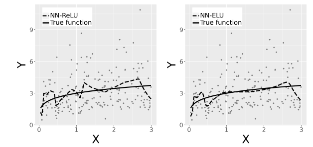

**DGP** (solid): Cobb-Douglas

**Estimated** (dashed): DNN with $L=2$

**Point:** DNN fit is neither monotone nor concave

### **Theorem**

A DNN is a valid production function if, for each hidden layer $\ell$:

1. The activation $\sigma^{(\ell)}(\cdot)$ is **concave**, **non-decreasing**, and satisfies $\sigma^{(\ell)}(0)=0$.
2. All weights and biases are **non-negative**:

$$W^{(\ell)} \ge 0,
\qquad
\mathbf{w}_0^{(\ell)} \ge 0.$$

Compositions of non-decreasing concave functions with non-negative affine maps remain monotone and concave.

$$\text{DNN}(\mathbf{X};\mathbf{w}_0) = (\sigma^{(L)} \circ W^{(L)}\circ\cdots \sigma^{(1)} \circ W^{(1)})(\mathbf{X})$$

Built-in architecture rather than after-estimation adjustements, rejection-sampling, etc

### New activations: CReLU and CELU

### Concave ReLU

$$\sigma(t)=
\begin{cases}
\alpha t, & t\ge 0,\quad 0<\alpha<1 \\
t, & t<0
\end{cases}$$

Piecewise linear and concave.

### Concave ELU

$$\sigma(t)=
\begin{cases}
-\alpha(e^{-t}-1), & t\ge 0 \\
t, & t<0
\end{cases}$$

Smooth, concave, and non-decreasing.

These activations should be used when estimating DNN for production functions.

They also retain universal approximation properties of traditional DNNs – see paper.

They also have no vanishing gradient problem – see paper.

A longer list of activations in the paper, each having its own computational appeals

### DNN-SFM with CReLU and CELU

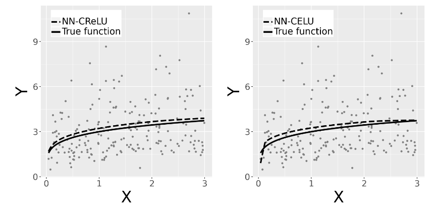

**DGP** (solid): Cobb-Douglas

**Estimated** (dashed): DNN with $L=2$

**Point:** DNN fit is both monotone and concave

### Estimation and inference

$$\varepsilon_i= Y_i - DNN(\mathbf{X}_i;\mathbf{w}) \qquad \theta = (\mathbf{w}, \sigma_v^2, \sigma_u^2)$$
$$\text{Loss }L({\theta}) = \sum\limits_{i=1}^n \{-\ell_i({\theta}|\boldsymbol X_i,Y_i)\}, \text{ where }\ell_i({\theta}|\boldsymbol X_i,Y_i) = -\frac{1}{2}\log\left(\frac{\pi}{2}\right) - \frac{1}{2}\log\left(\sqrt{\sigma_v^2+\sigma_u^2}\right) + \log\Phi\left( -\frac{\sigma_u\varepsilon_i}{\sigma_v\sqrt{\sigma_v^2+\sigma_u^2}} \right) - \frac{\varepsilon_i^2}{{2(\sigma_v^2+\sigma_u^2})}.$$

Training by mini-batch stochastic gradient descent:
$$\theta_{t+1}
\leftarrow
\theta_t - a\frac{1}{|B_t|}
\sum_{i\in B_t}\nabla_\theta L(\theta)$$
with automatic differentiation and backpropagation, batch size $|B_t|$, learning rate $a$.

Inference using bootstrap.

Using Pytorch library in Python 3.

**Note:** unconstrained loss minimization problem with no extra computational tools beyond standard DNN.

### Model selection and hyperparameter tuning

- number of layers
- hidden nodes
- other architectural hyperparameters (a, |B_t|)

**Leave‐one‐out cross‐validation (LOOCV)** to tune over a grid of candidate architectures varying in depth ($L=1, 2, 3$) and in width ($2^2$, $2^3$, $2^4$ and $2^5$ hidden nodes per layer) and over a grid of $a$ between 0.1 and 0.01, with $|B|=n$ when feasible.

### Interpretation: SHAP values

DNNs are flexible, but not naturally interpretable. The paper uses SHAP values:

$$DNN(x;\widehat w)
= \phi_0 + \sum_{k=1}^K \phi_k(x).$$

For input $j$ from a full set $[K]$:

$$\phi_j(x)=
\frac{1}{K}\sum_{S\subseteq[K]\setminus\{j\}}
{K-1 \choose |S|}^{-1}
\left[\nu_{S\cup\{j\}}(x)-\nu_S(x)\right].$$

SHAP gives local input contributions, not marginal products or elasticities.

Shows how the prediction changes as inputs are included against a background distribution.

**Note:** new results on inference for SHAP:

- “Shapley Values: Paired-Sampling Approximations” by M Mayer and M Wuethrich
- “Profit and loss decomposition in continuous time and approximations” by G Junike, H Stier and M Christiansen

### Simulation design

Three DGPs, two Cobb-Douglas, one Translog

### DGP 1

Single relevant input:

$$Y_i = \beta_0 X_{1i}^{\beta_1}\exp(V_i-U_i).$$

### DGP 2

Includes irrelevant regressors:

$$Y_i = \beta_0 X_{1i}^{\beta_1}X_{2i}^{0}X_{3i}^{0}X_{4i}^{0}\exp(V_i-U_i).$$

### DGP 3

$$Y_i
=
\beta_0
X_{1i}^{\beta_1}
X_{2i}^{\beta_2}
\exp\!\left[
\tfrac{1}{2}\beta_{11} (\ln X_{1i})^2
+ \tfrac{1}{2}\beta_{22} (\ln X_{2i})^2
+ \beta_{12} \ln X_{1i}\ln X_{2i}
\right]
\exp(V_i-U_i),$$

Compared estimators:

**Linear SFM, GAM-SFM, BART-SFM, DNN-ReLU, DNN-ELU, DNN-CReLU, DNN-CELU**.

### Simulation results

| DGP | Best Parametric | Best Unconstrained DNN | Best Shape-Aware DNN |
| --- | --- | --- | --- |
| DGP1 (Cobb-Douglas) | Lin | DNN-ELU (RMSE=0.583) | **DNN-CReLU (0.510)** |
| DGP2 (+ irrelevant regressors) | Lin | DNN-ELU (1.025) | **DNN-CReLU (0.394)** |
| DGP3 (Translog) | Translog | DNN-ReLU (0.404) | **DNN-CReLU (0.347)** |

Parametric models dominate only if true.

Shape-aware DNNs outperform unconstrained DNNs and other flexible estimators in almost any metric.

Better recovers inefficiency – lowest Bias$_u$ and Bias$_{TE}$.

More robust to irrelevant regressors.

More robust to misspecification risk – even a misspecified Translog performs worse than shape-aware DNNs.

Few instances of wrong-skewness.

### Computational Cost

Average runtime over 10 replications.

Trained in PyTorch using Adam optimization.

| Estimator | Runtime (sec) |
| --- | --- |
| Lin (misspecified) | 0.02 |
| Translog | 0.03 |
| GAM-SFM | 0.05 |
| BART-SFM | 78.00 |
| DNN-ReLU | 1.06 |
| DNN-ELU | 1.10 |
| DNN-CReLU | 1.20 |
| DNN-CELU | 5.52 |

Accuracy gains come at modest computational cost

### Empirical application: Philippine rice farms

Data:

- 43 small-holder rice farms
- Tarlac region, Philippines, 1992
- Output: freshly threshed rice
- Inputs: Area, Labor, NPK fertilizer

Models fitted: **Linear SFM, BART-SFM, DNN-ELU, DNN-CELU**

Linear SFM shows wrong-skew problem and estimates $\widehat\sigma_u=0$, fails to produce efficiency scores in this example.

Flexible methods produce TE scores, only DNN-CELU produces monotone and concave partial dependence.

### Empirical findings

**Efficiency estimates**

- BART efficiencies are high and tightly concentrated
- NN-ELU and SNN-CELU efficiency scores are more dispersed
- DNN-CELU score have a wider range and trimodal TE distribution

**Shape behavior**

- DNN-CELU partial dependence is monotone and concave
- NN-ELU becomes non-monotone for some inputs
- SHAPs show nonlinear input contributions and interactions:
  - NPK and Labor interact

### Concluding remarks

- Parametric SFMs are interpretable but fragile.
- Ordinary DNNs are flexible but can violate production theory.
- Shape-aware DNNs impose monotonicity and concavity by construction.
- CReLU and CELU are feasible choices for standard backpropagation.
- SHAP gives local partial dependence interpretation, but not classical marginal products.
- **Potential extensions**:
  - DNN in frontier and in moments of $U$
  - extensions to panels, spatial, etc.
  - dependence-aware DNN
  - uncertainty quantification for SHAP values

### Things to advertise

[figure not shown]

**GitHub** for this paper

with all Python codes and data

[figure not shown]

**Doing SFA with Python: Adapting New Estimators to a High-Performance Computing Environment** (with Yu Ma and Zheng Wei)

in **Handbook on Research Methods and Applications in Productivity and Efficiency**, Daraio, Cinzia (Ed.), 2026, Edward Edgar

[figure not shown]

**iCEBDA26** in Xiamen, 4-7 Dec 2026

**Keynotes**: Mark Hallin (U Libre de Bruxelles), Peter Hansen (UNC Chapel Hill), Hashem Pesaran (U Combridge), Yixiao Sun (UC San Diego)